# Untitled

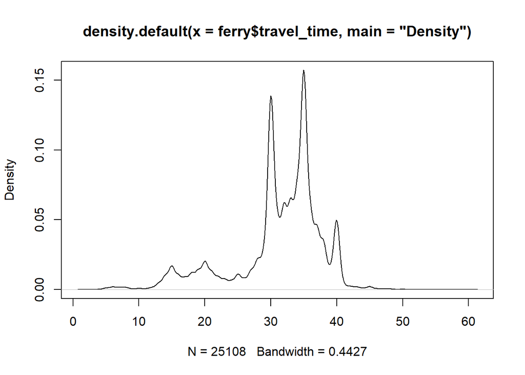

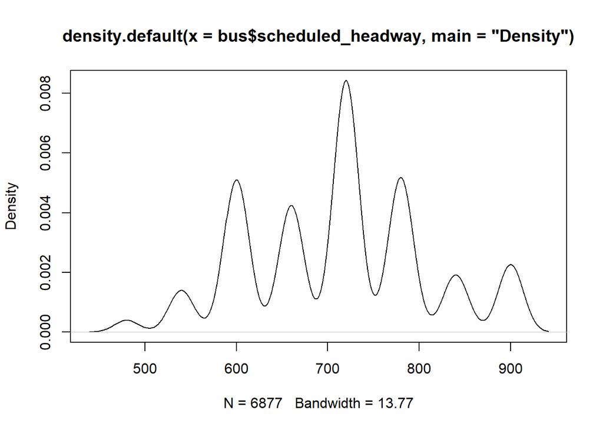

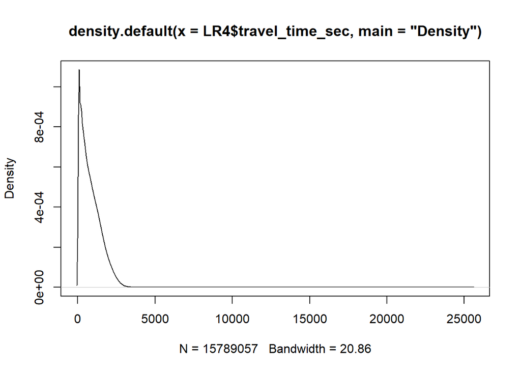

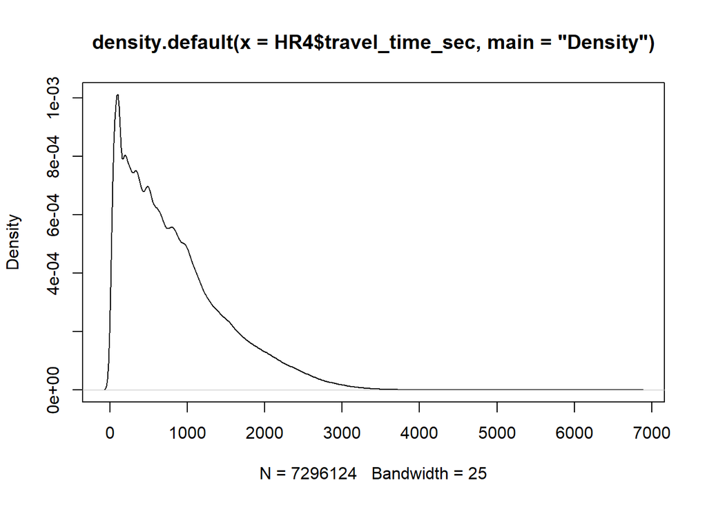

## Mapping

To better help the shiny, i try to plot the MBTA lines/plots on the fixed map around Boston.

The first map is for railway around Boston.

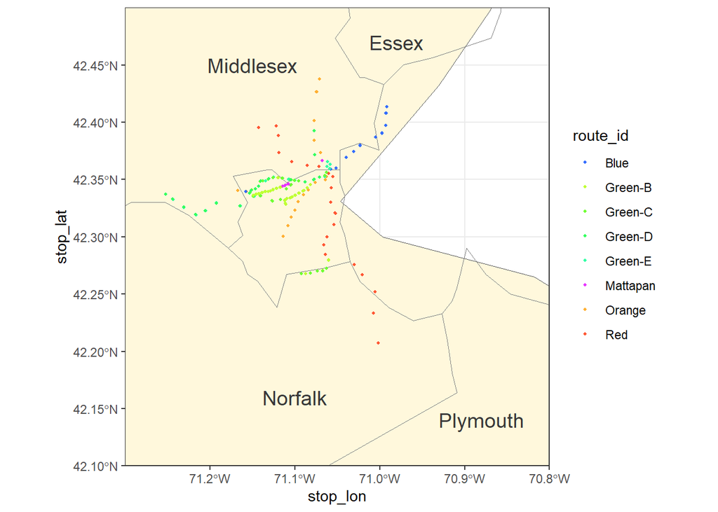

The second map is for bus station start position around Boston.

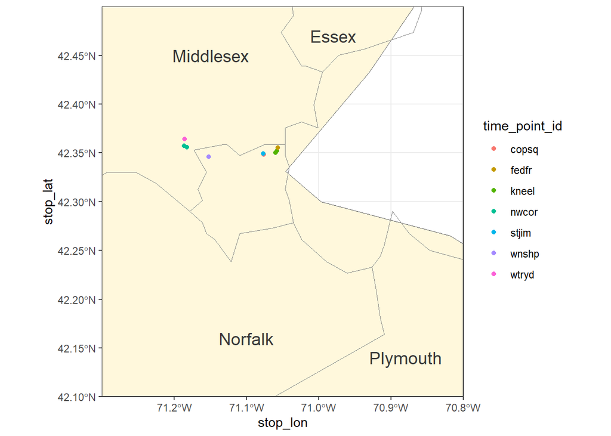

The third map is for ferry trip depart location around Boston.

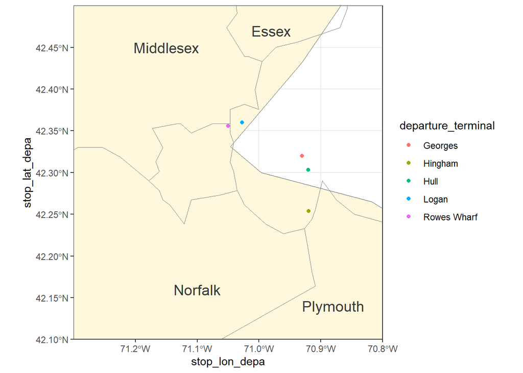

The last map is for railway line around Boston.

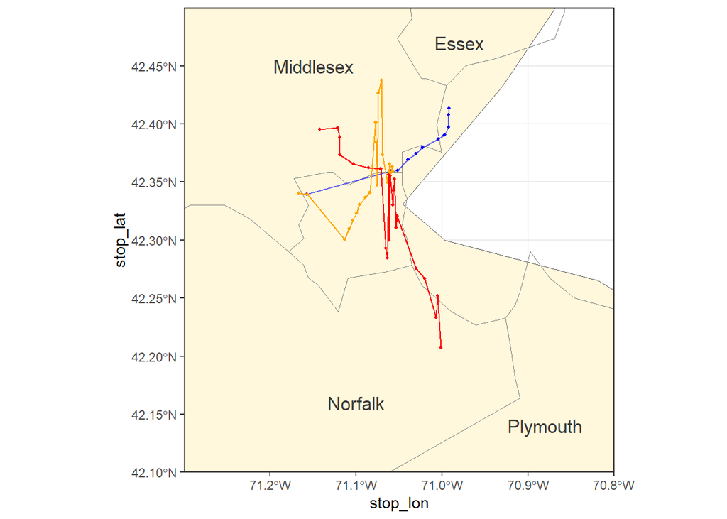

## Shiny

Sorry the shiny failed.

Shiny applications not supported in static R Markdown documents

Shiny applications not supported in static R Markdown documents